# Risk Factor Analysis

## Outcome Variable

**Outcome Variable:** ever_co

## Predictor Variables

**Intervention Variable:** enstunt

**Adjustment Set:**

- arm
- sex
- W_mage
- meducyrs
- feducyrs
- vagbrth
- single
- brthmon
- W_parity
- delta_W_mage
- delta_meducyrs
- delta_feducyrs
- delta_vagbrth
- delta_single
- delta_brthmon
- delta_W_parity

## Stratifying Variables

The analysis was stratified on these variable(s):

- agecat
- studyid
- country

## Data Summary

| agecat | studyid | country | enstunt | ever_co | n_cell | n |
| --- | --- | --- | --- | --- | --- | --- |
| 0-24 months | ki0047075b-MAL-ED | BANGLADESH | 0 | 0 | 193 | 263 |
| 0-24 months | ki0047075b-MAL-ED | BANGLADESH | 0 | 1 | 24 | 263 |
| 0-24 months | ki0047075b-MAL-ED | BANGLADESH | 1 | 0 | 31 | 263 |
| 0-24 months | ki0047075b-MAL-ED | BANGLADESH | 1 | 1 | 15 | 263 |
| 0-24 months | ki0047075b-MAL-ED | BRAZIL | 0 | 0 | 201 | 233 |
| 0-24 months | ki0047075b-MAL-ED | BRAZIL | 0 | 1 | 1 | 233 |
| 0-24 months | ki0047075b-MAL-ED | BRAZIL | 1 | 0 | 29 | 233 |
| 0-24 months | ki0047075b-MAL-ED | BRAZIL | 1 | 1 | 2 | 233 |
| 0-24 months | ki0047075b-MAL-ED | INDIA | 0 | 0 | 174 | 251 |
| 0-24 months | ki0047075b-MAL-ED | INDIA | 0 | 1 | 36 | 251 |
| 0-24 months | ki0047075b-MAL-ED | INDIA | 1 | 0 | 23 | 251 |
| 0-24 months | ki0047075b-MAL-ED | INDIA | 1 | 1 | 18 | 251 |
| 0-24 months | ki0047075b-MAL-ED | NEPAL | 0 | 0 | 201 | 240 |
| 0-24 months | ki0047075b-MAL-ED | NEPAL | 0 | 1 | 10 | 240 |
| 0-24 months | ki0047075b-MAL-ED | NEPAL | 1 | 0 | 17 | 240 |
| 0-24 months | ki0047075b-MAL-ED | NEPAL | 1 | 1 | 12 | 240 |
| 0-24 months | ki0047075b-MAL-ED | PERU | 0 | 0 | 260 | 302 |
| 0-24 months | ki0047075b-MAL-ED | PERU | 0 | 1 | 6 | 302 |
| 0-24 months | ki0047075b-MAL-ED | PERU | 1 | 0 | 30 | 302 |
| 0-24 months | ki0047075b-MAL-ED | PERU | 1 | 1 | 6 | 302 |
| 0-24 months | ki0047075b-MAL-ED | SOUTH AFRICA | 0 | 0 | 257 | 312 |
| 0-24 months | ki0047075b-MAL-ED | SOUTH AFRICA | 0 | 1 | 17 | 312 |
| 0-24 months | ki0047075b-MAL-ED | SOUTH AFRICA | 1 | 0 | 32 | 312 |
| 0-24 months | ki0047075b-MAL-ED | SOUTH AFRICA | 1 | 1 | 6 | 312 |
| 0-24 months | ki0047075b-MAL-ED | TANZANIA, UNITED REPUBLIC OF | 0 | 0 | 203 | 261 |
| 0-24 months | ki0047075b-MAL-ED | TANZANIA, UNITED REPUBLIC OF | 0 | 1 | 16 | 261 |
| 0-24 months | ki0047075b-MAL-ED | TANZANIA, UNITED REPUBLIC OF | 1 | 0 | 35 | 261 |
| 0-24 months | ki0047075b-MAL-ED | TANZANIA, UNITED REPUBLIC OF | 1 | 1 | 7 | 261 |
| 0-24 months | ki1000108-CMC-V-BCS-2002 | INDIA | 0 | 0 | 248 | 373 |
| 0-24 months | ki1000108-CMC-V-BCS-2002 | INDIA | 0 | 1 | 48 | 373 |

[output cut: 338 more lines]

The following strata were considered:

- agecat: 0-24 months, studyid: ki0047075b-MAL-ED, country: BANGLADESH
- agecat: 0-24 months, studyid: ki0047075b-MAL-ED, country: BRAZIL
- agecat: 0-24 months, studyid: ki0047075b-MAL-ED, country: INDIA
- agecat: 0-24 months, studyid: ki0047075b-MAL-ED, country: NEPAL
- agecat: 0-24 months, studyid: ki0047075b-MAL-ED, country: PERU
- agecat: 0-24 months, studyid: ki0047075b-MAL-ED, country: SOUTH AFRICA
- agecat: 0-24 months, studyid: ki0047075b-MAL-ED, country: TANZANIA, UNITED REPUBLIC OF
- agecat: 0-24 months, studyid: ki1000108-CMC-V-BCS-2002, country: INDIA
- agecat: 0-24 months, studyid: ki1000108-IRC, country: INDIA
- agecat: 0-24 months, studyid: ki1000109-EE, country: PAKISTAN
- agecat: 0-24 months, studyid: ki1000109-ResPak, country: PAKISTAN
- agecat: 0-24 months, studyid: ki1000304b-SAS-CompFeed, country: INDIA
- agecat: 0-24 months, studyid: ki1000304b-SAS-FoodSuppl, country: INDIA
- agecat: 0-24 months, studyid: ki1017093-NIH-Birth, country: BANGLADESH
- agecat: 0-24 months, studyid: ki1017093b-PROVIDE, country: BANGLADESH
- agecat: 0-24 months, studyid: ki1017093c-NIH-Crypto, country: BANGLADESH
- agecat: 0-24 months, studyid: ki1066203-TanzaniaChild2, country: TANZANIA, UNITED REPUBLIC OF
- agecat: 0-24 months, studyid: ki1101329-Keneba, country: GAMBIA
- agecat: 0-24 months, studyid: ki1112895-Guatemala BSC, country: GUATEMALA
- agecat: 0-24 months, studyid: ki1112895-iLiNS-Zinc, country: BURKINA FASO
- agecat: 0-24 months, studyid: ki1113344-GMS-Nepal, country: NEPAL
- agecat: 0-24 months, studyid: ki1114097-CMIN, country: BANGLADESH
- agecat: 0-24 months, studyid: ki1114097-CONTENT, country: PERU
- agecat: 0-24 months, studyid: ki1119695-PROBIT, country: BELARUS
- agecat: 0-24 months, studyid: ki1126311-ZVITAMBO, country: ZIMBABWE
- agecat: 0-24 months, studyid: ki1135781-COHORTS, country: GUATEMALA
- agecat: 0-24 months, studyid: ki1135781-COHORTS, country: INDIA
- agecat: 0-24 months, studyid: ki1135781-COHORTS, country: PHILIPPINES
- agecat: 0-24 months, studyid: ki1148112-LCNI-5, country: MALAWI
- agecat: 0-24 months, studyid: kiGH5241-JiVitA-3, country: BANGLADESH
- agecat: 0-24 months, studyid: kiGH5241-JiVitA-4, country: BANGLADESH
- agecat: 0-6 months, studyid: ki0047075b-MAL-ED, country: BANGLADESH
- agecat: 0-6 months, studyid: ki0047075b-MAL-ED, country: BRAZIL
- agecat: 0-6 months, studyid: ki0047075b-MAL-ED, country: INDIA
- agecat: 0-6 months, studyid: ki0047075b-MAL-ED, country: NEPAL
- agecat: 0-6 months, studyid: ki0047075b-MAL-ED, country: PERU
- agecat: 0-6 months, studyid: ki0047075b-MAL-ED, country: SOUTH AFRICA
- agecat: 0-6 months, studyid: ki0047075b-MAL-ED, country: TANZANIA, UNITED REPUBLIC OF
- agecat: 0-6 months, studyid: ki1000108-CMC-V-BCS-2002, country: INDIA
- agecat: 0-6 months, studyid: ki1000108-IRC, country: INDIA
- agecat: 0-6 months, studyid: ki1000109-EE, country: PAKISTAN
- agecat: 0-6 months, studyid: ki1000109-ResPak, country: PAKISTAN
- agecat: 0-6 months, studyid: ki1000304b-SAS-CompFeed, country: INDIA
- agecat: 0-6 months, studyid: ki1000304b-SAS-FoodSuppl, country: INDIA
- agecat: 0-6 months, studyid: ki1017093-NIH-Birth, country: BANGLADESH
- agecat: 0-6 months, studyid: ki1017093b-PROVIDE, country: BANGLADESH
- agecat: 0-6 months, studyid: ki1017093c-NIH-Crypto, country: BANGLADESH
- agecat: 0-6 months, studyid: ki1066203-TanzaniaChild2, country: TANZANIA, UNITED REPUBLIC OF
- agecat: 0-6 months, studyid: ki1101329-Keneba, country: GAMBIA
- agecat: 0-6 months, studyid: ki1112895-Guatemala BSC, country: GUATEMALA
- agecat: 0-6 months, studyid: ki1113344-GMS-Nepal, country: NEPAL
- agecat: 0-6 months, studyid: ki1114097-CMIN, country: BANGLADESH
- agecat: 0-6 months, studyid: ki1114097-CONTENT, country: PERU
- agecat: 0-6 months, studyid: ki1119695-PROBIT, country: BELARUS
- agecat: 0-6 months, studyid: ki1126311-ZVITAMBO, country: ZIMBABWE
- agecat: 0-6 months, studyid: ki1135781-COHORTS, country: GUATEMALA
- agecat: 0-6 months, studyid: ki1135781-COHORTS, country: INDIA
- agecat: 0-6 months, studyid: ki1135781-COHORTS, country: PHILIPPINES
- agecat: 0-6 months, studyid: ki1148112-LCNI-5, country: MALAWI
- agecat: 0-6 months, studyid: kiGH5241-JiVitA-3, country: BANGLADESH
- agecat: 0-6 months, studyid: kiGH5241-JiVitA-4, country: BANGLADESH
- agecat: 6-24 months, studyid: ki0047075b-MAL-ED, country: BANGLADESH
- agecat: 6-24 months, studyid: ki0047075b-MAL-ED, country: BRAZIL
- agecat: 6-24 months, studyid: ki0047075b-MAL-ED, country: INDIA
- agecat: 6-24 months, studyid: ki0047075b-MAL-ED, country: NEPAL
- agecat: 6-24 months, studyid: ki0047075b-MAL-ED, country: PERU
- agecat: 6-24 months, studyid: ki0047075b-MAL-ED, country: SOUTH AFRICA
- agecat: 6-24 months, studyid: ki0047075b-MAL-ED, country: TANZANIA, UNITED REPUBLIC OF
- agecat: 6-24 months, studyid: ki1000108-CMC-V-BCS-2002, country: INDIA
- agecat: 6-24 months, studyid: ki1000108-IRC, country: INDIA
- agecat: 6-24 months, studyid: ki1000109-EE, country: PAKISTAN
- agecat: 6-24 months, studyid: ki1000109-ResPak, country: PAKISTAN
- agecat: 6-24 months, studyid: ki1000304b-SAS-CompFeed, country: INDIA
- agecat: 6-24 months, studyid: ki1000304b-SAS-FoodSuppl, country: INDIA
- agecat: 6-24 months, studyid: ki1017093-NIH-Birth, country: BANGLADESH
- agecat: 6-24 months, studyid: ki1017093b-PROVIDE, country: BANGLADESH
- agecat: 6-24 months, studyid: ki1017093c-NIH-Crypto, country: BANGLADESH
- agecat: 6-24 months, studyid: ki1066203-TanzaniaChild2, country: TANZANIA, UNITED REPUBLIC OF
- agecat: 6-24 months, studyid: ki1101329-Keneba, country: GAMBIA
- agecat: 6-24 months, studyid: ki1112895-Guatemala BSC, country: GUATEMALA
- agecat: 6-24 months, studyid: ki1112895-iLiNS-Zinc, country: BURKINA FASO
- agecat: 6-24 months, studyid: ki1113344-GMS-Nepal, country: NEPAL
- agecat: 6-24 months, studyid: ki1114097-CMIN, country: BANGLADESH
- agecat: 6-24 months, studyid: ki1114097-CONTENT, country: PERU
- agecat: 6-24 months, studyid: ki1119695-PROBIT, country: BELARUS
- agecat: 6-24 months, studyid: ki1126311-ZVITAMBO, country: ZIMBABWE
- agecat: 6-24 months, studyid: ki1135781-COHORTS, country: GUATEMALA
- agecat: 6-24 months, studyid: ki1135781-COHORTS, country: INDIA
- agecat: 6-24 months, studyid: ki1135781-COHORTS, country: PHILIPPINES
- agecat: 6-24 months, studyid: ki1148112-LCNI-5, country: MALAWI
- agecat: 6-24 months, studyid: kiGH5241-JiVitA-3, country: BANGLADESH
- agecat: 6-24 months, studyid: kiGH5241-JiVitA-4, country: BANGLADESH

### Dropped Strata

Some strata were dropped due to rare outcomes:

- agecat: 0-24 months, studyid: ki0047075b-MAL-ED, country: BRAZIL
- agecat: 0-24 months, studyid: ki1114097-CONTENT, country: PERU
- agecat: 0-24 months, studyid: ki1119695-PROBIT, country: BELARUS
- agecat: 0-6 months, studyid: ki0047075b-MAL-ED, country: BANGLADESH
- agecat: 0-6 months, studyid: ki0047075b-MAL-ED, country: BRAZIL
- agecat: 0-6 months, studyid: ki0047075b-MAL-ED, country: NEPAL
- agecat: 0-6 months, studyid: ki0047075b-MAL-ED, country: PERU
- agecat: 0-6 months, studyid: ki0047075b-MAL-ED, country: SOUTH AFRICA
- agecat: 0-6 months, studyid: ki0047075b-MAL-ED, country: TANZANIA, UNITED REPUBLIC OF
- agecat: 0-6 months, studyid: ki1000109-ResPak, country: PAKISTAN
- agecat: 0-6 months, studyid: ki1000304b-SAS-FoodSuppl, country: INDIA
- agecat: 0-6 months, studyid: ki1017093c-NIH-Crypto, country: BANGLADESH
- agecat: 0-6 months, studyid: ki1112895-Guatemala BSC, country: GUATEMALA
- agecat: 0-6 months, studyid: ki1114097-CMIN, country: BANGLADESH
- agecat: 0-6 months, studyid: ki1114097-CONTENT, country: PERU
- agecat: 0-6 months, studyid: ki1119695-PROBIT, country: BELARUS
- agecat: 0-6 months, studyid: ki1135781-COHORTS, country: GUATEMALA
- agecat: 0-6 months, studyid: ki1148112-LCNI-5, country: MALAWI
- agecat: 6-24 months, studyid: ki0047075b-MAL-ED, country: BRAZIL
- agecat: 6-24 months, studyid: ki0047075b-MAL-ED, country: SOUTH AFRICA
- agecat: 6-24 months, studyid: ki1114097-CONTENT, country: PERU
- agecat: 6-24 months, studyid: ki1119695-PROBIT, country: BELARUS

## Methods Detail

We’re interested in the causal parameters $E[Y_a]$ for all values of $a \in \mathcal{A}$. These parameters represent the mean outcome if, possibly contrary to fact, we intervened to set all units to have $A=a$. Under the randomization and positivity assumptions, these are identified by the statistical parameters $\psi_a=E_W[E_{Y|A,W}(Y|A=a,W)]$. In addition, we’re interested in the mean of $Y$, $E[Y]$ under no intervention (the observed mean). We will estimate these parameters by using SuperLearner to fit the relevant likelihood factors – $E_{Y|A,W}(Y|A=a,W)$ and $p(A=a|W)$, and then updating our likelihood fit using a joint TMLE.

For unadjusted analyses ($W=\{\}$), initial likelihoods were estimated using Lrnr_glm to estimate the simple $E(Y|A)$ and Lrnr_mean to estimate $p(A)$. For adjusted analyses, a small library containing Lrnr_glmnet, Lrnr_xgboost, and Lrnr_mean was used.

Having estimated these parameters, we will then use the delta method to estimate relative risks and attributable risks relative to a prespecified baseline level of $A$.

# Results Detail

## Results Plots

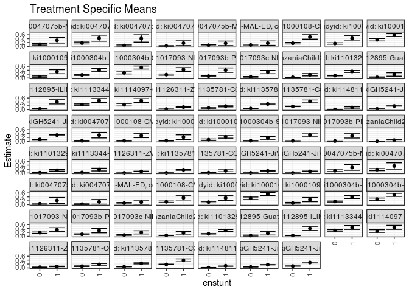

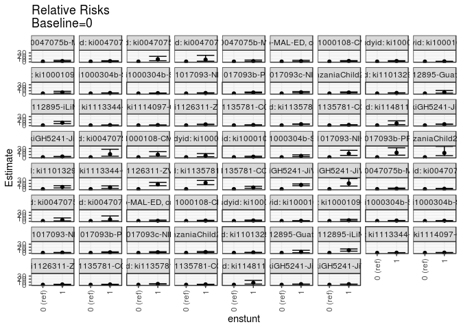

[figure not shown]

[figure not shown]

## Results Table

### Parameter: TSM

| agecat | studyid | country | intervention_level | baseline_level | estimate | ci_lower | ci_upper |
| --- | --- | --- | --- | --- | --- | --- | --- |
| 0-24 months | ki0047075b-MAL-ED | BANGLADESH | 0 | NA | 0.1109579 | 0.0689876 | 0.1529283 |
| 0-24 months | ki0047075b-MAL-ED | BANGLADESH | 1 | NA | 0.3130286 | 0.1701754 | 0.4558818 |
| 0-24 months | ki0047075b-MAL-ED | INDIA | 0 | NA | 0.1733442 | 0.1218973 | 0.2247911 |
| 0-24 months | ki0047075b-MAL-ED | INDIA | 1 | NA | 0.4214733 | 0.2657961 | 0.5771505 |
| 0-24 months | ki0047075b-MAL-ED | NEPAL | 0 | NA | 0.0474409 | 0.0186405 | 0.0762413 |
| 0-24 months | ki0047075b-MAL-ED | NEPAL | 1 | NA | 0.4094928 | 0.2201126 | 0.5988731 |
| 0-24 months | ki0047075b-MAL-ED | PERU | 0 | NA | 0.0225564 | 0.0046830 | 0.0404298 |
| 0-24 months | ki0047075b-MAL-ED | PERU | 1 | NA | 0.1666667 | 0.0447254 | 0.2886080 |
| 0-24 months | ki0047075b-MAL-ED | SOUTH AFRICA | 0 | NA | 0.0620438 | 0.0334343 | 0.0906533 |
| 0-24 months | ki0047075b-MAL-ED | SOUTH AFRICA | 1 | NA | 0.1578947 | 0.0417712 | 0.2740183 |
| 0-24 months | ki0047075b-MAL-ED | TANZANIA, UNITED REPUBLIC OF | 0 | NA | 0.0730594 | 0.0385272 | 0.1075915 |
| 0-24 months | ki0047075b-MAL-ED | TANZANIA, UNITED REPUBLIC OF | 1 | NA | 0.1666667 | 0.0537415 | 0.2795918 |
| 0-24 months | ki1000108-CMC-V-BCS-2002 | INDIA | 0 | NA | 0.1643895 | 0.1220601 | 0.2067189 |
| 0-24 months | ki1000108-CMC-V-BCS-2002 | INDIA | 1 | NA | 0.4890223 | 0.3739686 | 0.6040759 |
| 0-24 months | ki1000108-IRC | INDIA | 0 | NA | 0.1494245 | 0.1124212 | 0.1864279 |
| 0-24 months | ki1000108-IRC | INDIA | 1 | NA | 0.4157547 | 0.2848255 | 0.5466839 |
| 0-24 months | ki1000109-EE | PAKISTAN | 0 | NA | 0.3434461 | 0.2792328 | 0.4076595 |
| 0-24 months | ki1000109-EE | PAKISTAN | 1 | NA | 0.5797473 | 0.5051426 | 0.6543519 |
| 0-24 months | ki1000109-ResPak | PAKISTAN | 0 | NA | 0.0726409 | 0.0368556 | 0.1084262 |
| 0-24 months | ki1000109-ResPak | PAKISTAN | 1 | NA | 0.3275928 | 0.2219785 | 0.4332072 |
| 0-24 months | ki1000304b-SAS-CompFeed | INDIA | 0 | NA | 0.1618190 | 0.1317969 | 0.1918411 |
| 0-24 months | ki1000304b-SAS-CompFeed | INDIA | 1 | NA | 0.4112776 | 0.3282340 | 0.4943213 |
| 0-24 months | ki1000304b-SAS-FoodSuppl | INDIA | 0 | NA | 0.2652125 | 0.2112508 | 0.3191741 |
| 0-24 months | ki1000304b-SAS-FoodSuppl | INDIA | 1 | NA | 0.5400115 | 0.4621682 | 0.6178548 |
| 0-24 months | ki1017093-NIH-Birth | BANGLADESH | 0 | NA | 0.1757868 | 0.1432545 | 0.2083192 |
| 0-24 months | ki1017093-NIH-Birth | BANGLADESH | 1 | NA | 0.4414763 | 0.3443534 | 0.5385991 |
| 0-24 months | ki1017093b-PROVIDE | BANGLADESH | 0 | NA | 0.0993729 | 0.0760201 | 0.1227257 |
| 0-24 months | ki1017093b-PROVIDE | BANGLADESH | 1 | NA | 0.4070418 | 0.2904246 | 0.5236589 |
| 0-24 months | ki1017093c-NIH-Crypto | BANGLADESH | 0 | NA | 0.0628203 | 0.0441989 | 0.0814418 |
| 0-24 months | ki1017093c-NIH-Crypto | BANGLADESH | 1 | NA | 0.3078499 | 0.2206383 | 0.3950616 |

[output cut: 110 more lines]

### Parameter: E(Y)

| agecat | studyid | country | intervention_level | baseline_level | estimate | ci_lower | ci_upper |
| --- | --- | --- | --- | --- | --- | --- | --- |
| 0-24 months | ki0047075b-MAL-ED | BANGLADESH | NA | NA | 0.1482890 | 0.1052563 | 0.1913216 |
| 0-24 months | ki0047075b-MAL-ED | INDIA | NA | NA | 0.2151394 | 0.1642023 | 0.2660766 |
| 0-24 months | ki0047075b-MAL-ED | NEPAL | NA | NA | 0.0916667 | 0.0550838 | 0.1282495 |
| 0-24 months | ki0047075b-MAL-ED | PERU | NA | NA | 0.0397351 | 0.0176679 | 0.0618023 |
| 0-24 months | ki0047075b-MAL-ED | SOUTH AFRICA | NA | NA | 0.0737179 | 0.0446760 | 0.1027599 |
| 0-24 months | ki0047075b-MAL-ED | TANZANIA, UNITED REPUBLIC OF | NA | NA | 0.0881226 | 0.0536659 | 0.1225793 |
| 0-24 months | ki1000108-CMC-V-BCS-2002 | INDIA | NA | NA | 0.2305630 | 0.1877616 | 0.2733644 |
| 0-24 months | ki1000108-IRC | INDIA | NA | NA | 0.1853659 | 0.1477057 | 0.2230261 |
| 0-24 months | ki1000109-EE | PAKISTAN | NA | NA | 0.4485488 | 0.3984116 | 0.4986861 |
| 0-24 months | ki1000109-ResPak | PAKISTAN | NA | NA | 0.1478873 | 0.1065284 | 0.1892462 |
| 0-24 months | ki1000304b-SAS-CompFeed | INDIA | NA | NA | 0.2319894 | 0.1917264 | 0.2722524 |
| 0-24 months | ki1000304b-SAS-FoodSuppl | INDIA | NA | NA | 0.3708134 | 0.3244530 | 0.4171738 |
| 0-24 months | ki1017093-NIH-Birth | BANGLADESH | NA | NA | 0.2195513 | 0.1870467 | 0.2520558 |
| 0-24 months | ki1017093b-PROVIDE | BANGLADESH | NA | NA | 0.1285714 | 0.1037574 | 0.1533855 |
| 0-24 months | ki1017093c-NIH-Crypto | BANGLADESH | NA | NA | 0.0936675 | 0.0729118 | 0.1144233 |
| 0-24 months | ki1066203-TanzaniaChild2 | TANZANIA, UNITED REPUBLIC OF | NA | NA | 0.0496661 | 0.0409652 | 0.0583670 |
| 0-24 months | ki1101329-Keneba | GAMBIA | NA | NA | 0.1483007 | 0.1353925 | 0.1612090 |
| 0-24 months | ki1112895-Guatemala BSC | GUATEMALA | NA | NA | 0.0730159 | 0.0442400 | 0.1017917 |
| 0-24 months | ki1112895-iLiNS-Zinc | BURKINA FASO | NA | NA | 0.1246554 | 0.1041227 | 0.1451882 |
| 0-24 months | ki1113344-GMS-Nepal | NEPAL | NA | NA | 0.2944606 | 0.2603274 | 0.3285938 |
| 0-24 months | ki1114097-CMIN | BANGLADESH | NA | NA | 0.3394834 | 0.2830004 | 0.3959663 |
| 0-24 months | ki1126311-ZVITAMBO | ZIMBABWE | NA | NA | 0.0423899 | 0.0390454 | 0.0457344 |
| 0-24 months | ki1135781-COHORTS | GUATEMALA | NA | NA | 0.1104522 | 0.0937191 | 0.1271852 |
| 0-24 months | ki1135781-COHORTS | INDIA | NA | NA | 0.0894353 | 0.0829338 | 0.0959368 |
| 0-24 months | ki1135781-COHORTS | PHILIPPINES | NA | NA | 0.1839080 | 0.1701456 | 0.1976705 |
| 0-24 months | ki1148112-LCNI-5 | MALAWI | NA | NA | 0.0511905 | 0.0362780 | 0.0661030 |
| 0-24 months | kiGH5241-JiVitA-3 | BANGLADESH | NA | NA | 0.0888460 | 0.0849398 | 0.0927521 |
| 0-24 months | kiGH5241-JiVitA-4 | BANGLADESH | NA | NA | 0.1613377 | 0.1500063 | 0.1726692 |
| 0-6 months | ki0047075b-MAL-ED | INDIA | NA | NA | 0.0756972 | 0.0429084 | 0.1084860 |
| 0-6 months | ki1000108-CMC-V-BCS-2002 | INDIA | NA | NA | 0.0842391 | 0.0558231 | 0.1126551 |
| 0-6 months | ki1000108-IRC | INDIA | NA | NA | 0.0611247 | 0.0378797 | 0.0843697 |
| 0-6 months | ki1000109-EE | PAKISTAN | NA | NA | 0.1503958 | 0.1143605 | 0.1864311 |
| 0-6 months | ki1000304b-SAS-CompFeed | INDIA | NA | NA | 0.0704787 | 0.0478990 | 0.0930584 |
| 0-6 months | ki1017093-NIH-Birth | BANGLADESH | NA | NA | 0.0723473 | 0.0519719 | 0.0927227 |
| 0-6 months | ki1017093b-PROVIDE | BANGLADESH | NA | NA | 0.0428571 | 0.0278427 | 0.0578716 |
| 0-6 months | ki1066203-TanzaniaChild2 | TANZANIA, UNITED REPUBLIC OF | NA | NA | 0.0079299 | 0.0043777 | 0.0114821 |
| 0-6 months | ki1101329-Keneba | GAMBIA | NA | NA | 0.0284322 | 0.0218657 | 0.0349987 |
| 0-6 months | ki1113344-GMS-Nepal | NEPAL | NA | NA | 0.0524781 | 0.0357793 | 0.0691770 |
| 0-6 months | ki1126311-ZVITAMBO | ZIMBABWE | NA | NA | 0.0120612 | 0.0102430 | 0.0138795 |
| 0-6 months | ki1135781-COHORTS | INDIA | NA | NA | 0.0259576 | 0.0222658 | 0.0296495 |
| 0-6 months | ki1135781-COHORTS | PHILIPPINES | NA | NA | 0.0236531 | 0.0182537 | 0.0290525 |
| 0-6 months | kiGH5241-JiVitA-3 | BANGLADESH | NA | NA | 0.0396778 | 0.0371765 | 0.0421791 |
| 0-6 months | kiGH5241-JiVitA-4 | BANGLADESH | NA | NA | 0.0265122 | 0.0211694 | 0.0318550 |
| 6-24 months | ki0047075b-MAL-ED | BANGLADESH | NA | NA | 0.1464435 | 0.1015265 | 0.1913605 |
| 6-24 months | ki0047075b-MAL-ED | INDIA | NA | NA | 0.2000000 | 0.1487493 | 0.2512507 |
| 6-24 months | ki0047075b-MAL-ED | NEPAL | NA | NA | 0.0680851 | 0.0358110 | 0.1003592 |
| 6-24 months | ki0047075b-MAL-ED | PERU | NA | NA | 0.0407407 | 0.0171167 | 0.0643648 |
| 6-24 months | ki0047075b-MAL-ED | TANZANIA, UNITED REPUBLIC OF | NA | NA | 0.0857143 | 0.0505889 | 0.1208396 |
| 6-24 months | ki1000108-CMC-V-BCS-2002 | INDIA | NA | NA | 0.1876676 | 0.1479906 | 0.2273445 |
| 6-24 months | ki1000108-IRC | INDIA | NA | NA | 0.1560976 | 0.1209228 | 0.1912723 |
| 6-24 months | ki1000109-EE | PAKISTAN | NA | NA | 0.4193548 | 0.3691429 | 0.4695668 |
| 6-24 months | ki1000109-ResPak | PAKISTAN | NA | NA | 0.1313559 | 0.0881682 | 0.1745436 |
| 6-24 months | ki1000304b-SAS-CompFeed | INDIA | NA | NA | 0.2260619 | 0.1909133 | 0.2612105 |
| 6-24 months | ki1000304b-SAS-FoodSuppl | INDIA | NA | NA | 0.3615960 | 0.3145115 | 0.4086805 |
| 6-24 months | ki1017093-NIH-Birth | BANGLADESH | NA | NA | 0.2103321 | 0.1759902 | 0.2446740 |
| 6-24 months | ki1017093b-PROVIDE | BANGLADESH | NA | NA | 0.1221498 | 0.0962275 | 0.1480722 |
| 6-24 months | ki1017093c-NIH-Crypto | BANGLADESH | NA | NA | 0.0863014 | 0.0659171 | 0.1066856 |
| 6-24 months | ki1066203-TanzaniaChild2 | TANZANIA, UNITED REPUBLIC OF | NA | NA | 0.0560238 | 0.0459853 | 0.0660623 |
| 6-24 months | ki1101329-Keneba | GAMBIA | NA | NA | 0.1469835 | 0.1337108 | 0.1602563 |
| 6-24 months | ki1112895-Guatemala BSC | GUATEMALA | NA | NA | 0.0649819 | 0.0359016 | 0.0940623 |
| 6-24 months | ki1112895-iLiNS-Zinc | BURKINA FASO | NA | NA | 0.1246554 | 0.1041227 | 0.1451882 |
| 6-24 months | ki1113344-GMS-Nepal | NEPAL | NA | NA | 0.3254237 | 0.2875855 | 0.3632619 |
| 6-24 months | ki1114097-CMIN | BANGLADESH | NA | NA | 0.3426295 | 0.2837999 | 0.4014590 |
| 6-24 months | ki1126311-ZVITAMBO | ZIMBABWE | NA | NA | 0.0410617 | 0.0373214 | 0.0448020 |
| 6-24 months | ki1135781-COHORTS | GUATEMALA | NA | NA | 0.1116585 | 0.0939639 | 0.1293530 |
| 6-24 months | ki1135781-COHORTS | INDIA | NA | NA | 0.0831652 | 0.0766672 | 0.0896632 |
| 6-24 months | ki1135781-COHORTS | PHILIPPINES | NA | NA | 0.1908832 | 0.1763448 | 0.2054216 |
| 6-24 months | ki1148112-LCNI-5 | MALAWI | NA | NA | 0.0520581 | 0.0368996 | 0.0672166 |
| 6-24 months | kiGH5241-JiVitA-3 | BANGLADESH | NA | NA | 0.0869213 | 0.0822621 | 0.0915805 |
| 6-24 months | kiGH5241-JiVitA-4 | BANGLADESH | NA | NA | 0.1477252 | 0.1371297 | 0.1583206 |

### Parameter: RR

| agecat | studyid | country | intervention_level | baseline_level | estimate | ci_lower | ci_upper |
| --- | --- | --- | --- | --- | --- | --- | --- |
| 0-24 months | ki0047075b-MAL-ED | BANGLADESH | 0 | 0 | 1.000000 | 1.0000000 | 1.000000 |
| 0-24 months | ki0047075b-MAL-ED | BANGLADESH | 1 | 0 | 2.821146 | 1.5562705 | 5.114064 |
| 0-24 months | ki0047075b-MAL-ED | INDIA | 0 | 0 | 1.000000 | 1.0000000 | 1.000000 |
| 0-24 months | ki0047075b-MAL-ED | INDIA | 1 | 0 | 2.431424 | 1.5095532 | 3.916274 |
| 0-24 months | ki0047075b-MAL-ED | NEPAL | 0 | 0 | 1.000000 | 1.0000000 | 1.000000 |
| 0-24 months | ki0047075b-MAL-ED | NEPAL | 1 | 0 | 8.631642 | 4.0149920 | 18.556758 |
| 0-24 months | ki0047075b-MAL-ED | PERU | 0 | 0 | 1.000000 | 1.0000000 | 1.000000 |
| 0-24 months | ki0047075b-MAL-ED | PERU | 1 | 0 | 7.388889 | 2.5129690 | 21.725568 |
| 0-24 months | ki0047075b-MAL-ED | SOUTH AFRICA | 0 | 0 | 1.000000 | 1.0000000 | 1.000000 |
| 0-24 months | ki0047075b-MAL-ED | SOUTH AFRICA | 1 | 0 | 2.544892 | 1.0682645 | 6.062612 |
| 0-24 months | ki0047075b-MAL-ED | TANZANIA, UNITED REPUBLIC OF | 0 | 0 | 1.000000 | 1.0000000 | 1.000000 |
| 0-24 months | ki0047075b-MAL-ED | TANZANIA, UNITED REPUBLIC OF | 1 | 0 | 2.281250 | 0.9986000 | 5.211397 |
| 0-24 months | ki1000108-CMC-V-BCS-2002 | INDIA | 0 | 0 | 1.000000 | 1.0000000 | 1.000000 |
| 0-24 months | ki1000108-CMC-V-BCS-2002 | INDIA | 1 | 0 | 2.974778 | 2.0989880 | 4.215985 |
| 0-24 months | ki1000108-IRC | INDIA | 0 | 0 | 1.000000 | 1.0000000 | 1.000000 |
| 0-24 months | ki1000108-IRC | INDIA | 1 | 0 | 2.782372 | 1.8678759 | 4.144598 |
| 0-24 months | ki1000109-EE | PAKISTAN | 0 | 0 | 1.000000 | 1.0000000 | 1.000000 |
| 0-24 months | ki1000109-EE | PAKISTAN | 1 | 0 | 1.688030 | 1.3460843 | 2.116839 |
| 0-24 months | ki1000109-ResPak | PAKISTAN | 0 | 0 | 1.000000 | 1.0000000 | 1.000000 |
| 0-24 months | ki1000109-ResPak | PAKISTAN | 1 | 0 | 4.509758 | 2.5008937 | 8.132258 |
| 0-24 months | ki1000304b-SAS-CompFeed | INDIA | 0 | 0 | 1.000000 | 1.0000000 | 1.000000 |
| 0-24 months | ki1000304b-SAS-CompFeed | INDIA | 1 | 0 | 2.541590 | 2.1798108 | 2.963414 |
| 0-24 months | ki1000304b-SAS-FoodSuppl | INDIA | 0 | 0 | 1.000000 | 1.0000000 | 1.000000 |
| 0-24 months | ki1000304b-SAS-FoodSuppl | INDIA | 1 | 0 | 2.036147 | 1.5870780 | 2.612281 |
| 0-24 months | ki1017093-NIH-Birth | BANGLADESH | 0 | 0 | 1.000000 | 1.0000000 | 1.000000 |
| 0-24 months | ki1017093-NIH-Birth | BANGLADESH | 1 | 0 | 2.511430 | 1.8820907 | 3.351209 |
| 0-24 months | ki1017093b-PROVIDE | BANGLADESH | 0 | 0 | 1.000000 | 1.0000000 | 1.000000 |
| 0-24 months | ki1017093b-PROVIDE | BANGLADESH | 1 | 0 | 4.096104 | 2.8312877 | 5.925951 |
| 0-24 months | ki1017093c-NIH-Crypto | BANGLADESH | 0 | 0 | 1.000000 | 1.0000000 | 1.000000 |
| 0-24 months | ki1017093c-NIH-Crypto | BANGLADESH | 1 | 0 | 4.900482 | 3.2513417 | 7.386097 |

[output cut: 110 more lines]

### Parameter: PAR

| agecat | studyid | country | intervention_level | baseline_level | estimate | ci_lower | ci_upper |
| --- | --- | --- | --- | --- | --- | --- | --- |
| 0-24 months | ki0047075b-MAL-ED | BANGLADESH | 0 | NA | 0.0373310 | 0.0104223 | 0.0642398 |
| 0-24 months | ki0047075b-MAL-ED | INDIA | 0 | NA | 0.0417952 | 0.0127484 | 0.0708421 |
| 0-24 months | ki0047075b-MAL-ED | NEPAL | 0 | NA | 0.0442258 | 0.0174417 | 0.0710098 |
| 0-24 months | ki0047075b-MAL-ED | PERU | 0 | NA | 0.0171787 | 0.0015689 | 0.0327885 |
| 0-24 months | ki0047075b-MAL-ED | SOUTH AFRICA | 0 | NA | 0.0116742 | -0.0033029 | 0.0266512 |
| 0-24 months | ki0047075b-MAL-ED | TANZANIA, UNITED REPUBLIC OF | 0 | NA | 0.0150632 | -0.0043938 | 0.0345203 |
| 0-24 months | ki1000108-CMC-V-BCS-2002 | INDIA | 0 | NA | 0.0661735 | 0.0379765 | 0.0943704 |
| 0-24 months | ki1000108-IRC | INDIA | 0 | NA | 0.0359413 | 0.0160175 | 0.0558651 |
| 0-24 months | ki1000109-EE | PAKISTAN | 0 | NA | 0.1051027 | 0.0604042 | 0.1498012 |
| 0-24 months | ki1000109-ResPak | PAKISTAN | 0 | NA | 0.0752464 | 0.0410380 | 0.1094548 |
| 0-24 months | ki1000304b-SAS-CompFeed | INDIA | 0 | NA | 0.0701704 | 0.0521567 | 0.0881841 |
| 0-24 months | ki1000304b-SAS-FoodSuppl | INDIA | 0 | NA | 0.1056009 | 0.0670778 | 0.1441240 |
| 0-24 months | ki1017093-NIH-Birth | BANGLADESH | 0 | NA | 0.0437645 | 0.0256951 | 0.0618338 |
| 0-24 months | ki1017093b-PROVIDE | BANGLADESH | 0 | NA | 0.0291985 | 0.0160202 | 0.0423769 |
| 0-24 months | ki1017093c-NIH-Crypto | BANGLADESH | 0 | NA | 0.0308472 | 0.0173947 | 0.0442997 |
| 0-24 months | ki1066203-TanzaniaChild2 | TANZANIA, UNITED REPUBLIC OF | 0 | NA | 0.0092310 | 0.0049758 | 0.0134863 |
| 0-24 months | ki1101329-Keneba | GAMBIA | 0 | NA | 0.0227875 | 0.0164702 | 0.0291049 |
| 0-24 months | ki1112895-Guatemala BSC | GUATEMALA | 0 | NA | 0.0353590 | 0.0124312 | 0.0582868 |
| 0-24 months | ki1112895-iLiNS-Zinc | BURKINA FASO | 0 | NA | 0.0837161 | 0.0649609 | 0.1024712 |
| 0-24 months | ki1113344-GMS-Nepal | NEPAL | 0 | NA | 0.0338216 | 0.0165966 | 0.0510465 |
| 0-24 months | ki1114097-CMIN | BANGLADESH | 0 | NA | 0.0851475 | 0.0383690 | 0.1319260 |
| 0-24 months | ki1126311-ZVITAMBO | ZIMBABWE | 0 | NA | 0.0103365 | 0.0084355 | 0.0122374 |
| 0-24 months | ki1135781-COHORTS | GUATEMALA | 0 | NA | 0.0226349 | 0.0116868 | 0.0335830 |
| 0-24 months | ki1135781-COHORTS | INDIA | 0 | NA | 0.0288316 | 0.0247380 | 0.0329251 |
| 0-24 months | ki1135781-COHORTS | PHILIPPINES | 0 | NA | 0.0146174 | 0.0098656 | 0.0193691 |
| 0-24 months | ki1148112-LCNI-5 | MALAWI | 0 | NA | 0.0361246 | 0.0221970 | 0.0500522 |
| 0-24 months | kiGH5241-JiVitA-3 | BANGLADESH | 0 | NA | 0.0479771 | 0.0448488 | 0.0511054 |
| 0-24 months | kiGH5241-JiVitA-4 | BANGLADESH | 0 | NA | 0.0639053 | 0.0553831 | 0.0724275 |
| 0-6 months | ki0047075b-MAL-ED | INDIA | 0 | NA | 0.0471258 | 0.0200723 | 0.0741792 |
| 0-6 months | ki1000108-CMC-V-BCS-2002 | INDIA | 0 | NA | 0.0534172 | 0.0294136 | 0.0774209 |
| 0-6 months | ki1000108-IRC | INDIA | 0 | NA | 0.0266081 | 0.0101357 | 0.0430806 |
| 0-6 months | ki1000109-EE | PAKISTAN | 0 | NA | 0.0650137 | 0.0316334 | 0.0983941 |
| 0-6 months | ki1000304b-SAS-CompFeed | INDIA | 0 | NA | 0.0378225 | 0.0208005 | 0.0548444 |
| 0-6 months | ki1017093-NIH-Birth | BANGLADESH | 0 | NA | 0.0474696 | 0.0303827 | 0.0645565 |
| 0-6 months | ki1017093b-PROVIDE | BANGLADESH | 0 | NA | 0.0254702 | 0.0135938 | 0.0373466 |
| 0-6 months | ki1066203-TanzaniaChild2 | TANZANIA, UNITED REPUBLIC OF | 0 | NA | 0.0038994 | 0.0013207 | 0.0064781 |
| 0-6 months | ki1101329-Keneba | GAMBIA | 0 | NA | 0.0105576 | 0.0062566 | 0.0148585 |
| 0-6 months | ki1113344-GMS-Nepal | NEPAL | 0 | NA | 0.0247670 | 0.0122268 | 0.0373072 |
| 0-6 months | ki1126311-ZVITAMBO | ZIMBABWE | 0 | NA | 0.0073462 | 0.0058821 | 0.0088103 |
| 0-6 months | ki1135781-COHORTS | INDIA | 0 | NA | 0.0183334 | 0.0151561 | 0.0215106 |
| 0-6 months | ki1135781-COHORTS | PHILIPPINES | 0 | NA | 0.0054988 | 0.0026554 | 0.0083422 |
| 0-6 months | kiGH5241-JiVitA-3 | BANGLADESH | 0 | NA | 0.0324931 | 0.0301380 | 0.0348481 |
| 0-6 months | kiGH5241-JiVitA-4 | BANGLADESH | 0 | NA | 0.0224052 | 0.0173073 | 0.0275032 |
| 6-24 months | ki0047075b-MAL-ED | BANGLADESH | 0 | NA | 0.0271875 | 0.0019134 | 0.0524616 |
| 6-24 months | ki0047075b-MAL-ED | INDIA | 0 | NA | 0.0262788 | -0.0008682 | 0.0534257 |
| 6-24 months | ki0047075b-MAL-ED | NEPAL | 0 | NA | 0.0197759 | 0.0000540 | 0.0394979 |
| 6-24 months | ki0047075b-MAL-ED | PERU | 0 | NA | 0.0153170 | -0.0006592 | 0.0312932 |
| 6-24 months | ki0047075b-MAL-ED | TANZANIA, UNITED REPUBLIC OF | 0 | NA | 0.0080444 | -0.0098296 | 0.0259183 |
| 6-24 months | ki1000108-CMC-V-BCS-2002 | INDIA | 0 | NA | 0.0404004 | 0.0154987 | 0.0653022 |
| 6-24 months | ki1000108-IRC | INDIA | 0 | NA | 0.0264306 | 0.0082414 | 0.0446198 |
| 6-24 months | ki1000109-EE | PAKISTAN | 0 | NA | 0.0922758 | 0.0474254 | 0.1371262 |
| 6-24 months | ki1000109-ResPak | PAKISTAN | 0 | NA | 0.0519377 | 0.0185582 | 0.0853172 |
| 6-24 months | ki1000304b-SAS-CompFeed | INDIA | 0 | NA | 0.0635863 | 0.0463623 | 0.0808104 |
| 6-24 months | ki1000304b-SAS-FoodSuppl | INDIA | 0 | NA | 0.0781305 | 0.0388720 | 0.1173890 |
| 6-24 months | ki1017093-NIH-Birth | BANGLADESH | 0 | NA | 0.0231477 | 0.0057794 | 0.0405161 |
| 6-24 months | ki1017093b-PROVIDE | BANGLADESH | 0 | NA | 0.0186547 | 0.0062697 | 0.0310396 |
| 6-24 months | ki1017093c-NIH-Crypto | BANGLADESH | 0 | NA | 0.0210240 | 0.0089449 | 0.0331031 |
| 6-24 months | ki1066203-TanzaniaChild2 | TANZANIA, UNITED REPUBLIC OF | 0 | NA | 0.0090373 | 0.0043673 | 0.0137073 |
| 6-24 months | ki1101329-Keneba | GAMBIA | 0 | NA | 0.0181918 | 0.0120054 | 0.0243782 |
| 6-24 months | ki1112895-Guatemala BSC | GUATEMALA | 0 | NA | 0.0270673 | 0.0047788 | 0.0493557 |
| 6-24 months | ki1112895-iLiNS-Zinc | BURKINA FASO | 0 | NA | 0.0836748 | 0.0650475 | 0.1023022 |
| 6-24 months | ki1113344-GMS-Nepal | NEPAL | 0 | NA | 0.0245991 | 0.0063701 | 0.0428280 |
| 6-24 months | ki1114097-CMIN | BANGLADESH | 0 | NA | 0.0723745 | 0.0247824 | 0.1199665 |
| 6-24 months | ki1126311-ZVITAMBO | ZIMBABWE | 0 | NA | 0.0043847 | 0.0026715 | 0.0060979 |
| 6-24 months | ki1135781-COHORTS | GUATEMALA | 0 | NA | 0.0227401 | 0.0107731 | 0.0347071 |
| 6-24 months | ki1135781-COHORTS | INDIA | 0 | NA | 0.0207356 | 0.0169862 | 0.0244850 |
| 6-24 months | ki1135781-COHORTS | PHILIPPINES | 0 | NA | 0.0124347 | 0.0076901 | 0.0171794 |
| 6-24 months | ki1148112-LCNI-5 | MALAWI | 0 | NA | 0.0366141 | 0.0224339 | 0.0507942 |
| 6-24 months | kiGH5241-JiVitA-3 | BANGLADESH | 0 | NA | 0.0335733 | 0.0300562 | 0.0370903 |
| 6-24 months | kiGH5241-JiVitA-4 | BANGLADESH | 0 | NA | 0.0523095 | 0.0445111 | 0.0601079 |

### Parameter: PAF

| agecat | studyid | country | intervention_level | baseline_level | estimate | ci_lower | ci_upper |
| --- | --- | --- | --- | --- | --- | --- | --- |
| 0-24 months | ki0047075b-MAL-ED | BANGLADESH | 0 | NA | 0.2517452 | 0.0607289 | 0.4039152 |
| 0-24 months | ki0047075b-MAL-ED | INDIA | 0 | NA | 0.1942704 | 0.0526442 | 0.3147241 |
| 0-24 months | ki0047075b-MAL-ED | NEPAL | 0 | NA | 0.4824629 | 0.1957793 | 0.6669513 |
| 0-24 months | ki0047075b-MAL-ED | PERU | 0 | NA | 0.4323308 | 0.0107995 | 0.6742336 |
| 0-24 months | ki0047075b-MAL-ED | SOUTH AFRICA | 0 | NA | 0.1583624 | -0.0606925 | 0.3321780 |
| 0-24 months | ki0047075b-MAL-ED | TANZANIA, UNITED REPUBLIC OF | 0 | NA | 0.1709351 | -0.0708039 | 0.3581004 |
| 0-24 months | ki1000108-CMC-V-BCS-2002 | INDIA | 0 | NA | 0.2870083 | 0.1619056 | 0.3934368 |
| 0-24 months | ki1000108-IRC | INDIA | 0 | NA | 0.1938939 | 0.0841412 | 0.2904943 |
| 0-24 months | ki1000109-EE | PAKISTAN | 0 | NA | 0.2343172 | 0.1265616 | 0.3287790 |
| 0-24 months | ki1000109-ResPak | PAKISTAN | 0 | NA | 0.5088092 | 0.2751768 | 0.6671348 |
| 0-24 months | ki1000304b-SAS-CompFeed | INDIA | 0 | NA | 0.3024725 | 0.2463262 | 0.3544360 |
| 0-24 months | ki1000304b-SAS-FoodSuppl | INDIA | 0 | NA | 0.2847819 | 0.1742363 | 0.3805287 |
| 0-24 months | ki1017093-NIH-Birth | BANGLADESH | 0 | NA | 0.1993360 | 0.1158840 | 0.2749109 |
| 0-24 months | ki1017093b-PROVIDE | BANGLADESH | 0 | NA | 0.2270997 | 0.1257224 | 0.3167217 |
| 0-24 months | ki1017093c-NIH-Crypto | BANGLADESH | 0 | NA | 0.3293266 | 0.1900991 | 0.4446200 |
| 0-24 months | ki1066203-TanzaniaChild2 | TANZANIA, UNITED REPUBLIC OF | 0 | NA | 0.1858618 | 0.1021646 | 0.2617566 |
| 0-24 months | ki1101329-Keneba | GAMBIA | 0 | NA | 0.1536576 | 0.1115093 | 0.1938064 |
| 0-24 months | ki1112895-Guatemala BSC | GUATEMALA | 0 | NA | 0.4842641 | 0.1540456 | 0.6855818 |
| 0-24 months | ki1112895-iLiNS-Zinc | BURKINA FASO | 0 | NA | 0.6715796 | 0.5811758 | 0.7424696 |
| 0-24 months | ki1113344-GMS-Nepal | NEPAL | 0 | NA | 0.1148595 | 0.0548500 | 0.1710588 |
| 0-24 months | ki1114097-CMIN | BANGLADESH | 0 | NA | 0.2508150 | 0.1007681 | 0.3758249 |
| 0-24 months | ki1126311-ZVITAMBO | ZIMBABWE | 0 | NA | 0.2438427 | 0.2019030 | 0.2835785 |
| 0-24 months | ki1135781-COHORTS | GUATEMALA | 0 | NA | 0.2049296 | 0.1035205 | 0.2948673 |
| 0-24 months | ki1135781-COHORTS | INDIA | 0 | NA | 0.3223734 | 0.2808813 | 0.3614713 |
| 0-24 months | ki1135781-COHORTS | PHILIPPINES | 0 | NA | 0.0794819 | 0.0536734 | 0.1045866 |
| 0-24 months | ki1148112-LCNI-5 | MALAWI | 0 | NA | 0.7056891 | 0.4538749 | 0.8413937 |
| 0-24 months | kiGH5241-JiVitA-3 | BANGLADESH | 0 | NA | 0.5400033 | 0.5118550 | 0.5665284 |
| 0-24 months | kiGH5241-JiVitA-4 | BANGLADESH | 0 | NA | 0.3960962 | 0.3467880 | 0.4416823 |
| 0-6 months | ki0047075b-MAL-ED | INDIA | 0 | NA | 0.6225564 | 0.2796741 | 0.8022233 |
| 0-6 months | ki1000108-CMC-V-BCS-2002 | INDIA | 0 | NA | 0.6341140 | 0.3743864 | 0.7860140 |
| 0-6 months | ki1000108-IRC | INDIA | 0 | NA | 0.4353093 | 0.1736533 | 0.6141140 |
| 0-6 months | ki1000109-EE | PAKISTAN | 0 | NA | 0.4322843 | 0.1904769 | 0.6018629 |
| 0-6 months | ki1000304b-SAS-CompFeed | INDIA | 0 | NA | 0.5366506 | 0.3349567 | 0.6771750 |
| 0-6 months | ki1017093-NIH-Birth | BANGLADESH | 0 | NA | 0.6561356 | 0.4632155 | 0.7797203 |
| 0-6 months | ki1017093b-PROVIDE | BANGLADESH | 0 | NA | 0.5943040 | 0.3562763 | 0.7443170 |
| 0-6 months | ki1066203-TanzaniaChild2 | TANZANIA, UNITED REPUBLIC OF | 0 | NA | 0.4917388 | 0.1849308 | 0.6830582 |
| 0-6 months | ki1101329-Keneba | GAMBIA | 0 | NA | 0.3713248 | 0.2317377 | 0.4855501 |
| 0-6 months | ki1113344-GMS-Nepal | NEPAL | 0 | NA | 0.4719498 | 0.2440085 | 0.6311638 |
| 0-6 months | ki1126311-ZVITAMBO | ZIMBABWE | 0 | NA | 0.6090762 | 0.5203751 | 0.6813731 |
| 0-6 months | ki1135781-COHORTS | INDIA | 0 | NA | 0.7062806 | 0.6257988 | 0.7694527 |
| 0-6 months | ki1135781-COHORTS | PHILIPPINES | 0 | NA | 0.2324775 | 0.1162296 | 0.3334346 |
| 0-6 months | kiGH5241-JiVitA-3 | BANGLADESH | 0 | NA | 0.8189227 | 0.7865364 | 0.8463953 |
| 0-6 months | kiGH5241-JiVitA-4 | BANGLADESH | 0 | NA | 0.8450920 | 0.7385528 | 0.9082167 |
| 6-24 months | ki0047075b-MAL-ED | BANGLADESH | 0 | NA | 0.1856517 | 0.0015969 | 0.3357761 |
| 6-24 months | ki0047075b-MAL-ED | INDIA | 0 | NA | 0.1313939 | -0.0123562 | 0.2547322 |
| 6-24 months | ki0047075b-MAL-ED | NEPAL | 0 | NA | 0.2904589 | -0.0216670 | 0.5072283 |
| 6-24 months | ki0047075b-MAL-ED | PERU | 0 | NA | 0.3759630 | -0.0586014 | 0.6321353 |
| 6-24 months | ki0047075b-MAL-ED | TANZANIA, UNITED REPUBLIC OF | 0 | NA | 0.0938511 | -0.1368976 | 0.2777663 |
| 6-24 months | ki1000108-CMC-V-BCS-2002 | INDIA | 0 | NA | 0.2152766 | 0.0764332 | 0.3332471 |
| 6-24 months | ki1000108-IRC | INDIA | 0 | NA | 0.1693211 | 0.0490877 | 0.2743521 |
| 6-24 months | ki1000109-EE | PAKISTAN | 0 | NA | 0.2200423 | 0.1045801 | 0.3206159 |
| 6-24 months | ki1000109-ResPak | PAKISTAN | 0 | NA | 0.3953967 | 0.1211023 | 0.5840868 |
| 6-24 months | ki1000304b-SAS-CompFeed | INDIA | 0 | NA | 0.2812785 | 0.2223041 | 0.3357806 |
| 6-24 months | ki1000304b-SAS-FoodSuppl | INDIA | 0 | NA | 0.2160712 | 0.1003892 | 0.3168776 |
| 6-24 months | ki1017093-NIH-Birth | BANGLADESH | 0 | NA | 0.1100533 | 0.0246984 | 0.1879382 |
| 6-24 months | ki1017093b-PROVIDE | BANGLADESH | 0 | NA | 0.1527197 | 0.0493747 | 0.2448297 |
| 6-24 months | ki1017093c-NIH-Crypto | BANGLADESH | 0 | NA | 0.2436115 | 0.1021109 | 0.3628127 |
| 6-24 months | ki1066203-TanzaniaChild2 | TANZANIA, UNITED REPUBLIC OF | 0 | NA | 0.1613116 | 0.0789283 | 0.2363263 |
| 6-24 months | ki1101329-Keneba | GAMBIA | 0 | NA | 0.1237675 | 0.0817244 | 0.1638857 |
| 6-24 months | ki1112895-Guatemala BSC | GUATEMALA | 0 | NA | 0.4165350 | 0.0363123 | 0.6467410 |
| 6-24 months | ki1112895-iLiNS-Zinc | BURKINA FASO | 0 | NA | 0.6712491 | 0.5815937 | 0.7416932 |
| 6-24 months | ki1113344-GMS-Nepal | NEPAL | 0 | NA | 0.0755909 | 0.0179952 | 0.1298085 |
| 6-24 months | ki1114097-CMIN | BANGLADESH | 0 | NA | 0.2112324 | 0.0599673 | 0.3381568 |
| 6-24 months | ki1126311-ZVITAMBO | ZIMBABWE | 0 | NA | 0.1067832 | 0.0651822 | 0.1465330 |
| 6-24 months | ki1135781-COHORTS | GUATEMALA | 0 | NA | 0.2036575 | 0.0933425 | 0.3005503 |
| 6-24 months | ki1135781-COHORTS | INDIA | 0 | NA | 0.2493305 | 0.2068134 | 0.2895686 |
| 6-24 months | ki1135781-COHORTS | PHILIPPINES | 0 | NA | 0.0651432 | 0.0402096 | 0.0894291 |
| 6-24 months | ki1148112-LCNI-5 | MALAWI | 0 | NA | 0.7033312 | 0.4495815 | 0.8400992 |
| 6-24 months | kiGH5241-JiVitA-3 | BANGLADESH | 0 | NA | 0.3862492 | 0.3488668 | 0.4214854 |
| 6-24 months | kiGH5241-JiVitA-4 | BANGLADESH | 0 | NA | 0.3541003 | 0.3026110 | 0.4017880 |